# Turtle 2

### 2.4 Adding conditional statements

The last concept we want to work with is conditional statements. Let’s modify our code so that *if* the number of sizes is even, the turtle draws it on the left, but if the number of sizes is odd then it draws it on the right. To do that, we’re going to need to change the `turtle_polygon` function so that it has an `direction` argument that can either be `left` or `right`. The modified function looks like this:

```r
turtle_polygon <- function(sides, size, direction) {
  for(i in 1:sides) {
    turtle_forward(distance = size)  # move
    if(direction == "left") {
      turtle_left(angle = 360/sides) # turn
    } else {
      turtle_right(angle = 360/sides) # turn
    }
  }
}
```

**Test your understanding #1** Modify the code from the previous section so that the turtle now draws all the shapes on the other side. That is, make it draw this picture:

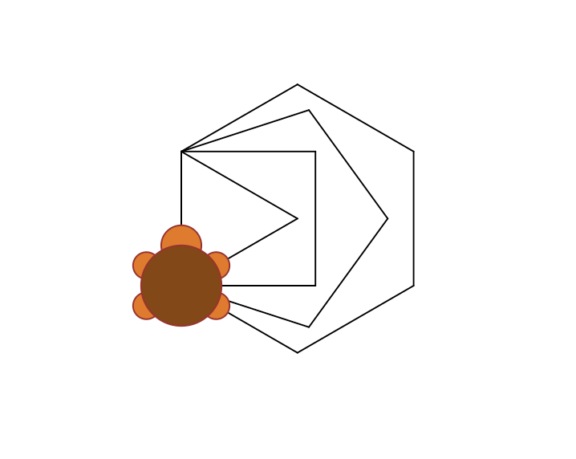

**Test your understanding #2** Modify the code again so that all the shapes with an even number of sides are on the left and all the shapes with an odd number of sides are on the right. That is, draw this:

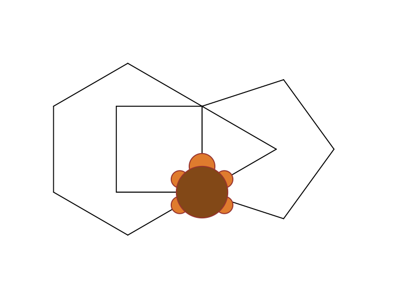

As a hint, here’s a simple function that can test for the evenness of a number using the `%%` operator that calculates the remainder after division:

```r
# define the function
is.even <- function(x) {
  return( x %% 2 == 0 )
}

# check that it works
is.even(2)
```

```
## [1] TRUE
```

```r
is.even(3)
```

```
## [1] FALSE
```

```r
is.even(4)
```

```
## [1] TRUE
```

### More?

Type `help(`TurtleGraphics-package`)` at the console to read the help documentation for the package. It documents a variety of other interesting things you can do with turtles. Have fun with your terrarium!